# Lab 3 - part 2

2022-10-05

#1. Hypothesis testing

The given population mean is 0.5. A new experiment produces new diamonds with the following weights:

```r
new.diamonds <- c(0.46, 0.61, 0.52, 0.48, 0.57, 0.54)
```

It is essential that the new process produces diamonds with a weight in excess of 0.50 carat. We have the following Hypothesis testing (1% significance level):

$H_0: \mu=0.5$ and $H_1: \mu \gt 0.5$

```r
t.test(new.diamonds, mu=0.5, alternative="greater", conf.level = 0.99)
```

[output not shown]

As seen, at a 99% confidence level, the p-value is greater than 0.05, thus we cannot reject $H_0.

For the next part of the lab, we are going to use the data on breast cancer.

```r
df <- read.csv("BreastCancer_Wisconsin.csv")
head(df)
```

```
##   diagnosis radius.mean radius.sd radius.max
## 1         M       17.99     10.38     122.80
## 2         M       20.57     17.77     132.90
## 3         M       19.69     21.25     130.00
## 4         M       11.42     20.38      77.58
## 5         M       20.29     14.34     135.10
## 6         M       12.45     15.70      82.57
```

Let’s explore the variables

```r
summary(df)
```

```
##   diagnosis          radius.mean       radius.sd       radius.max
##  Length:569         Min.   : 6.981   Min.   : 9.71   Min.   : 43.79
##  Class :character   1st Qu.:11.700   1st Qu.:16.17   1st Qu.: 75.17
##  Mode  :character   Median :13.370   Median :18.84   Median : 86.24
##                     Mean   :14.127   Mean   :19.29   Mean   : 91.97
##                     3rd Qu.:15.780   3rd Qu.:21.80   3rd Qu.:104.10
##                     Max.   :28.110   Max.   :39.28   Max.   :188.50
```

```r
# Changing diagnosis from a character type to a Factor
df$diagnosis <- as.factor(df$diagnosis)
summary(df$diagnosis)
```

```
##   B   M
## 357 212
```

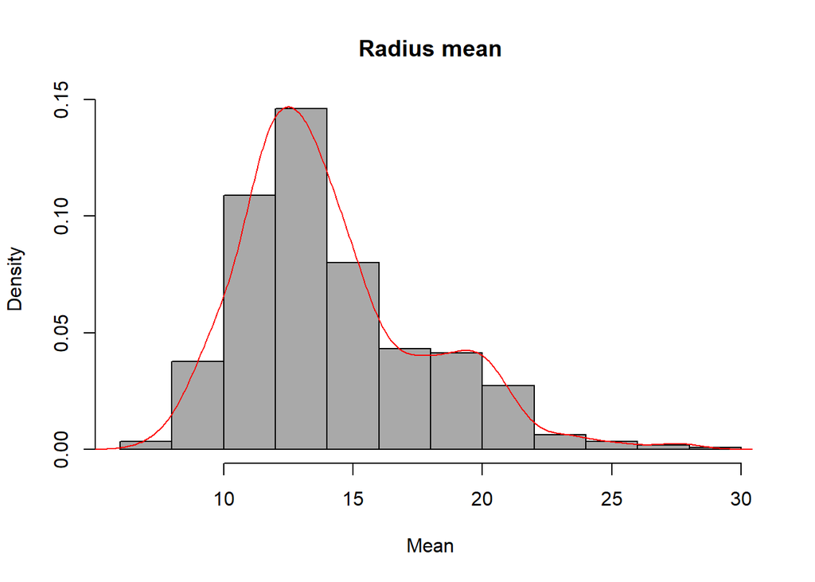

```r
hist(df$radius.mean,
     main="Radius mean",
     xlab="Mean",
     col="darkgray",
     prob = TRUE
     )
lines(density(df$radius.mean), col = "red")
```

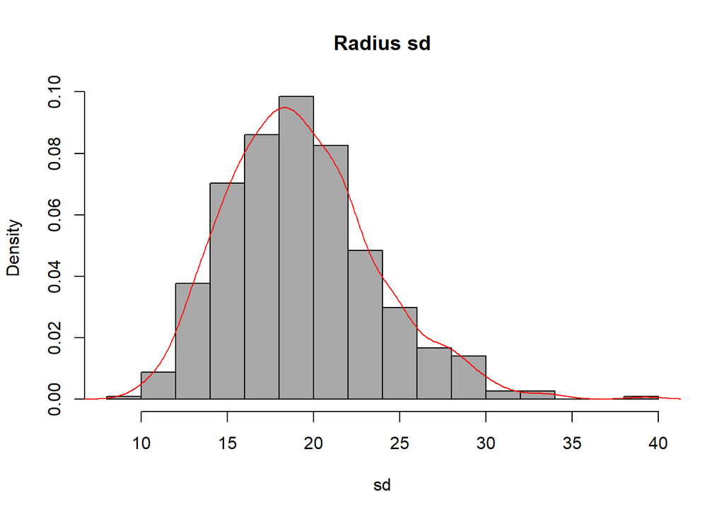

```r
hist(df$radius.sd,
     main="Radius sd",
     xlab="sd",
     col="darkgray",
     prob = TRUE
     )
lines(density(df$radius.sd), col = "red")
```

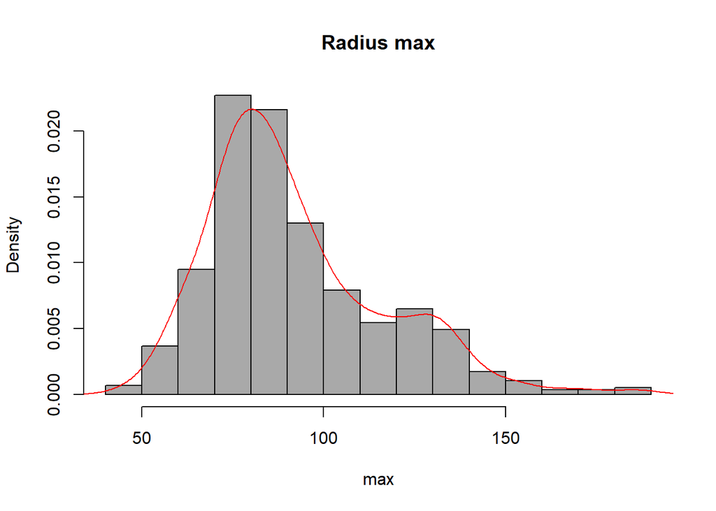

```r
hist(df$radius.max,
     main="Radius max",
     xlab="max",
     col="darkgray",
     prob = TRUE
     )
lines(density(df$radius.max), col = "red")
```

Almost all of them look normally distributed, but we can actually check this:

```r
shapiro.test(df$radius.mean)
```

```
##
##  Shapiro-Wilk normality test
##
## data:  df$radius.mean
## W = 0.94107, p-value = 3.106e-14
```

```r
shapiro.test(df$radius.sd)
```

```
##
##  Shapiro-Wilk normality test
##
## data:  df$radius.sd
## W = 0.97672, p-value = 7.284e-08
```

```r
shapiro.test(df$radius.max)
```

```
##
##  Shapiro-Wilk normality test
##
## data:  df$radius.max
## W = 0.93618, p-value = 7.011e-15
```

As seen, all p-values are very small, thus, we can reject the null hypothesis that these variables are normally distributed.

We can easily compute the proportion of benign tumours, looking at the table previously done

```r
357/length(df$diagnosis)
```

```
## [1] 0.6274165
```

Knowing the proportion of benign tumours of the population from which the data is drawn is 0.6, is the sample proportion equal?

$H_0: \mu=0.6$ and $H_1: \mu \ne 0.6$

```r
prop.test(357,length(df$diagnosis), p=0.6,alternative = "two.sided")
```

```
##
##  1-sample proportions test with continuity correction
##
## data:  357 out of length(df$diagnosis), null probability 0.6
## X-squared = 1.6697, df = 1, p-value = 0.1963
## alternative hypothesis: true p is not equal to 0.6
## 95 percent confidence interval:
##  0.5860680 0.6670184
## sample estimates:
##         p
## 0.6274165
```

As seen, the p-value is greater than 0.05, and therefore, we cannot reject the null hypothesis. Therefore, the proportions are the same for the sake of the problem.

Now, we explore the radius.mean attribute numerically and graphically:

```r
summary(df$radius.mean)
```

```
##    Min. 1st Qu.  Median    Mean 3rd Qu.    Max.
##   6.981  11.700  13.370  14.127  15.780  28.110
```

We have seen what it looks like graphically before. It is technically not normally distributed, but we will asumme it is just for the sake of the exercises.

Is there significant difference between the radius mean for benign v malignant? Let’s find out:

```r
b.tumours<-subset(df,df$diagnosis=="B")
m.tumours<-subset(df,df$diagnosis=="M")
```

Now this is our hypothesis:

$H_0: \mu_{b}=\mu_{m}$ $H_1: \mu_{b} \ne \mu_{b}$

```r
t.test(b.tumours$radius.mean,m.tumours$radius.mean, alternative = "two.sided")
```

```
##
##  Welch Two Sample t-test
##
## data:  b.tumours$radius.mean and m.tumours$radius.mean
## t = -22.209, df = 289.71, p-value < 2.2e-16
## alternative hypothesis: true difference in means is not equal to 0
## 95 percent confidence interval:
##  -5.787448 -4.845165
## sample estimates:
## mean of x mean of y
##  12.14652  17.46283
```

As the p-value is very small, we can reject the null hypothesis, and therefore confirm that both means are not equal. We can check this visually also:

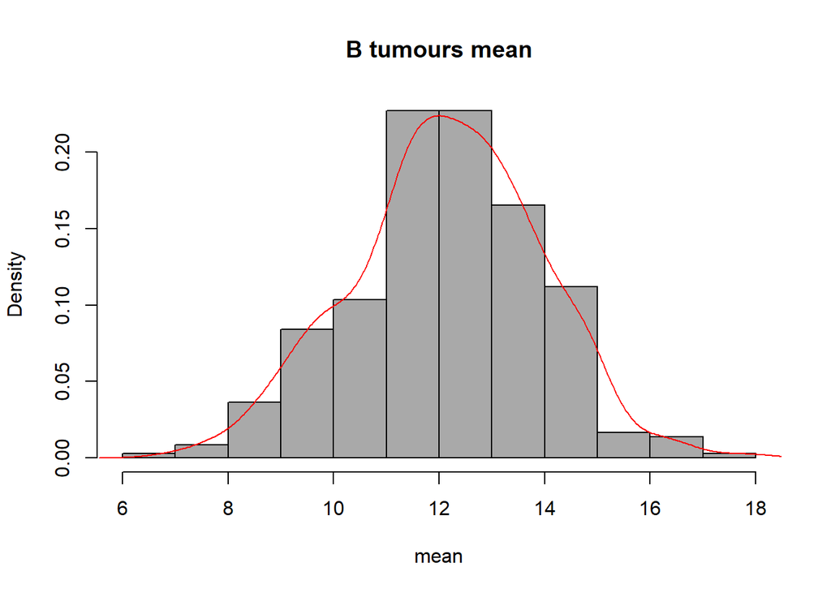

```r
hist(b.tumours$radius.mean,
     main="B tumours mean",
     xlab="mean",
     col="darkgray",
     prob = TRUE
     )
lines(density(b.tumours$radius.mean), col = "red")
```

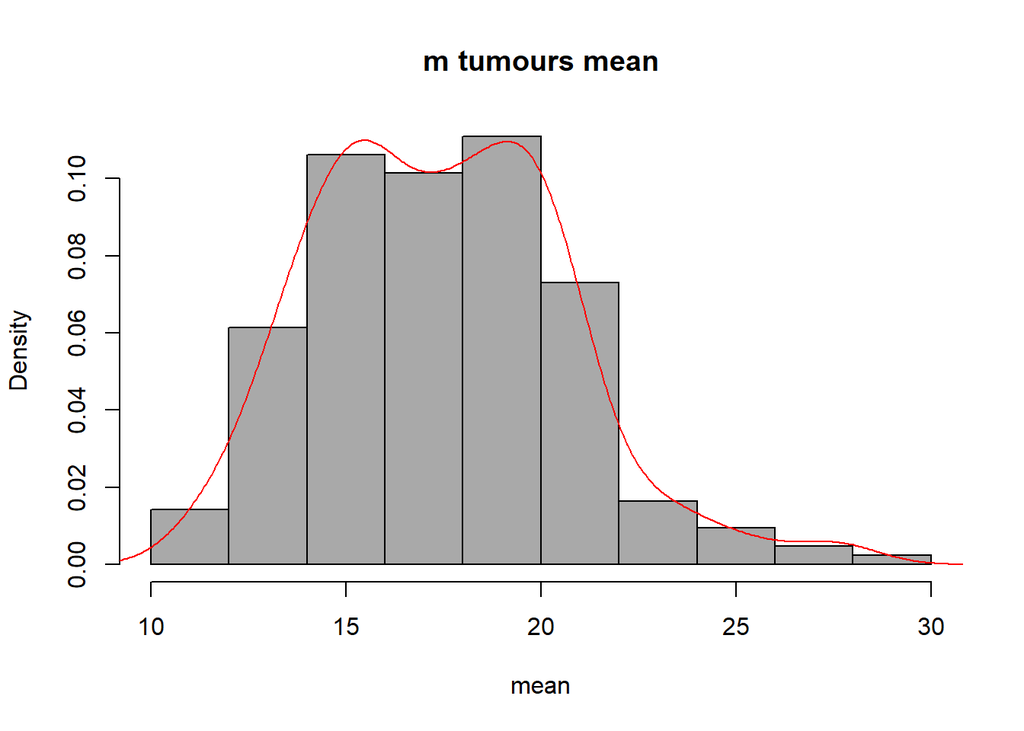

```r
hist(m.tumours$radius.mean,
     main="m tumours mean",
     xlab="mean",
     col="darkgray",
     prob = TRUE
     )
lines(density(m.tumours$radius.mean), col = "red")
```

Finally, we can compute the 95% CI for the proportion og benign tumours computed in c):

```r
prop.test(357, length(df$diagnosis), conf.level = 0.95)
```

```
##
##  1-sample proportions test with continuity correction
##
## data:  357 out of length(df$diagnosis), null probability 0.5
## X-squared = 36.443, df = 1, p-value = 1.572e-09
## alternative hypothesis: true p is not equal to 0.5
## 95 percent confidence interval:
##  0.5860680 0.6670184
## sample estimates:
##         p
## 0.6274165
```

Being the 95% CI (0.5860680, 0.6670184)